# Integrating plant-plant competition for nitrogen into a 3D individual-based model simulating the effects of cropping systems on weed dynamics - ScienceDirect

[figure not shown]

## Cited By (2)

## Figures (16)

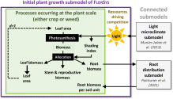

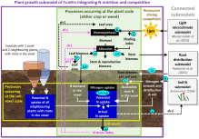

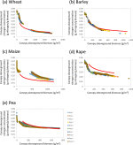

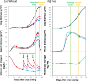

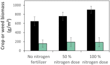

## Tables (1)

1. Table 1

## Extras (1)

1. Document

[figure not shown]

## [Field Crops Research](https://www.sciencedirect.com/journal/field-crops-research)

[Volume 268](https://www.sciencedirect.com/journal/field-crops-research/vol/268/suppl/C), 1 July 2021, 108166

# Integrating plant-plant competition for nitrogen into a 3D individual-based model simulating the effects of cropping systems on weed dynamics

[DelphineMoreau<sup>a</sup>](https://www.sciencedirect.com/science/article/abs/pii/S037842902100112X#!)[OliviaPointurier<sup>a</sup>](https://www.sciencedirect.com/science/article/abs/pii/S037842902100112X#!)[LaurènePerthame<sup>a</sup>](https://www.sciencedirect.com/science/article/abs/pii/S037842902100112X#!)[NicolasBeaudoin<sup>b</sup>](https://www.sciencedirect.com/science/article/abs/pii/S037842902100112X#!)[JeanVillerd<sup>a</sup><sup>c</sup>](https://www.sciencedirect.com/science/article/abs/pii/S037842902100112X#!)[NathalieColbach<sup>a</sup>](https://www.sciencedirect.com/science/article/abs/pii/S037842902100112X#!)

https://doi.org/10.1016/j.fcr.2021.108166[Get rights and content](https://s100.copyright.com/AppDispatchServlet?publisherName=ELS&contentID=S037842902100112X&orderBeanReset=true)

## Highlights

**•**

We complemented a 3D mechanistic cropping-system model of crop-weed interactions.

**•**

We made it the first one to include competition for nitrogen, in addition to light.

**•**

With only a few new parameters, simulations were consistent with previous knowledge.

**•**

We illustrate the role of this model to analyze crop-weed interactions in the field.

**•**

We show its potential as a tool to design biological weed management strategies.

## Abstract

Promoting biological weed regulation via competition for resources requires better understanding the functioning of heterogeneous canopies in nitrogen-deficient situations. Mechanistic simulation models are powerful tools to reach this goal. Our objective was to integrate plant-plant competition for nitrogen into the preexisting FlorSys model simulating the effects of cropping systems on weed dynamics and crop production. The formalisms were either created or inspired from other models and adapted to make them compatible with the individual-based representation of FlorSys. Plant nitrogen uptake was simulated by confronting plant nitrogen demand (driven by shoot growth) to plant nitrogen supply (depending on root characteristics, soil-nitrogen availability and the presence of neighboring plants with roots in the same soil zone). A nitrogen stress index allowed accounting for the impact of plant nitrogen nutrition on plant photosynthesis, biomass allocation and morphology. The new formalisms consisted of only seven species-specific parameters. Despite simplifying hypotheses in formalisms, predictions were in good agreement with knowledge on canopy functioning and crop-weed interactions. We provide the first mechanistic cropping system model focusing on weeds that simulates plant-plant competition for nitrogen (in addition to competition for light). It will be useful to understand the role of nitrogen in crop-weed interactions and identify agroecological management strategies promoting weed regulation by competition.

## Keywords

Weed

Nitrogen

Competition

Model

Cropping system

Biological regulation

## Cited by (2)

- 2022, Weed Research

### Weeding frequencies decreased rice–weed competition and increased rice n uptake in organic paddy field

- 2021, Agronomy

[View full text](https://www.sciencedirect.com/science/article/pii/S037842902100112X)

© 2021 Elsevier B.V. All rights reserved.

## Part of special issue:

[SI: Advances in crop modelling for ecological intensification](https://www.sciencedirect.com/science/journal/03784290/vsi/1082Z6Z3QTC)Edited by Marc Corbeels, Françoise Lescourret

- Field Crops Research, Volume 270, 2021, Article 108194

- Field Crops Research, Volume 268, 2021, Article 108174

- Field Crops Research, Volume 269, 2021, Article 108175

Citations

- Citation Indexes: 2

Captures

- Readers: 7

[figure not shown]

[figure not shown]